# Childhood socioeconomic position

# 1 Description of DataSchema variable

The description of harmonised variable is the following:

- Short name: `childsep`
- Variable label: `Childhood socioeconomic position`
- Variable description: `Childhood socioeconomic position`
- Domain: `Socio-demographic and economic characteristics`
- Value type: `Categorical`
- Category coding:

| **Code** | **Category Label** |
| --- | --- |
| 0 | High |
| 1 | Medium |
| 2 | Low |

- Category missings:

| **Code** | **Category Label** |
| --- | --- |
| 991 | CAPI/interviewer error |
| 992 | Impute |
| 993 | Disable to measure |
| 994 | Not attempt/not done |
| 995 | Does not answer |
| 996 | Not applicable |
| 997 | Refuse |
| 998 | Do not know |
| 999 | Missing |

# 2 Data process

## 2.1 England

### 2.1.1 Wave 1

#### 2.1.1.1 Study-specific variable description

| **Name** | `difjob` |
| --- | --- |
| **Label** | `What was your father~s (or main carer~s) job when you were 14?` |
| **Table name** | `wave_1_core_data_v3` |
| **Categories** | `1 = Armed Forces` `2 = Manager or senior official in someone else s business` `3 = Running his own business` `4 = Professional or technical` `5 = Administrative, clerical or secretarial` `6 = Skilled… |
| **Missings** | `-9 = Refusal` `-8 = Don't Know` `-1 = Not applicable` |
| **Description** |  |

DIFJOB

| Sample size | Missing values |
| --- | --- |
| 12099 | 184 |

Category

|  | 1 | 2 | 3 | 4 | 5 | 6 | 7 | 8 | 9 | 10 | 11 | 12 | 13 | 14 | 15 |
| --- | --- | --- | --- | --- | --- | --- | --- | --- | --- | --- | --- | --- | --- | --- | --- |
| Frequency | 334.00 | 555.00 | 904.00 | 1301.00 | 720.00 | 3344.00 | 214.00 | 310.00 | 1073.00 | 1907.00 | 675.00 | 175.00 | 93.00 | 178.00 | 132.00 |
| Percentage | 2.76 | 4.59 | 7.47 | 10.75 | 5.95 | 27.64 | 1.77 | 2.56 | 8.87 | 15.76 | 5.58 | 1.45 | 0.77 | 1.47 | 1.09 |

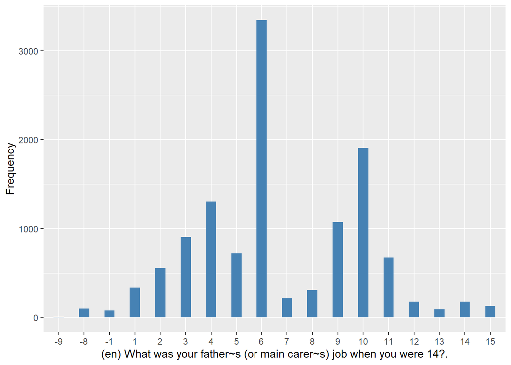

#### 2.1.1.2 Harmonisation algorithm

To compute `childsep` from the study-specific variable it has to be recoded as follows:

- `1,5:8 into 1`
- `2:4 into 0`
- `9:12,14:15 into 2`
- `-9 into 997`
- `-8 into 998`
- `-1 into 996`
- `13 into 999`

**R script:**

```r
ELSA_ds_w1 <- ELSA_w1 %>%
  mutate(childsep = case_when(
    difjob %in% c(2:4) ~ 0,
    difjob %in% c(1,5:8) ~ 1,
    difjob %in% c(9:12,14:15) ~ 2,
    difjob %in% c(-9) ~ 997,
    difjob %in% c(-8) ~ 998,
    difjob %in% c(-1) ~ 996,
    difjob %in% c(13) ~ 999,
    TRUE ~ 999
  )) %>%
  select(id, childsep)

ELSA_ds <- ELSA_ds_w1 %>%
  mutate(misscode = case_when(
    childsep %in% c(991:999) ~ 1,
    TRUE ~ 0
  ))
```

#### 2.1.1.3 Statistical description of the new harmonised variable

Childhood socioeconomic position

| Sample size | Missing values |
| --- | --- |
| 12099 | 277 |

Category

|  | 0 | 1 | 2 |
| --- | --- | --- | --- |
| Frequency | 2760.00 | 4922.00 | 4140.00 |
| Percentage | 22.81 | 40.68 | 34.22 |

Type of missing

|  | 991 | 992 | 993 | 994 | 995 | 996 | 997 | 998 | 999 | NA |
| --- | --- | --- | --- | --- | --- | --- | --- | --- | --- | --- |
| Frequency | 0 | 0 | 0 | 0 | 0 | 79.00 | 6.00 | 99.00 | 93.00 | 0 |
| Percentage | 0 | 0 | 0 | 0 | 0 | 0.65 | 0.05 | 0.82 | 0.77 | 0 |

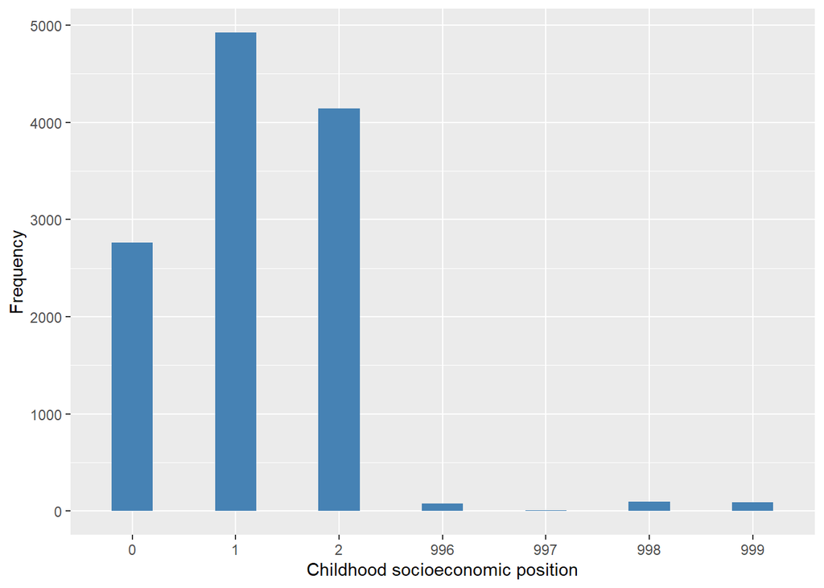

#### 2.1.1.4 Validation

### 2.1.2 Wave 2

#### 2.1.2.1 Study-specific variable description

| **Name** | `DiFJob` |
| --- | --- |
| **Label** | `What was your father~s (or main carer~s) job when you were 14?` |
| **Table name** | `wave_2_core_data_v4` |
| **Categories** | `1 = Armed Forces` `2 = Manager or senior official in someone else s business` `3 = Running his own business` `4 = Professional or technical` `5 = Administrative, clerical or secretarial` `6 = Skilled… |
| **Missings** | `-9 = Refusal` `-8 = Don't Know` `-1 = Not applicable` |
| **Description** |  |

DIFJOB

| Sample size | Missing values |
| --- | --- |
| 9432 | 9271 |

Category

|  | 1 | 2 | 3 | 4 | 5 | 6 | 7 | 8 | 9 | 10 | 11 | 12 | 13 | 14 | 15 |
| --- | --- | --- | --- | --- | --- | --- | --- | --- | --- | --- | --- | --- | --- | --- | --- |
| Frequency | 7.00 | 4.00 | 10.00 | 8.00 | 13.00 | 34.00 | 9.0 | 8.00 | 7.00 | 28.0 | 15.00 | 2.00 | 3.00 | 12.00 | 1.00 |
| Percentage | 0.07 | 0.04 | 0.11 | 0.08 | 0.14 | 0.36 | 0.1 | 0.08 | 0.07 | 0.3 | 0.16 | 0.02 | 0.03 | 0.13 | 0.01 |

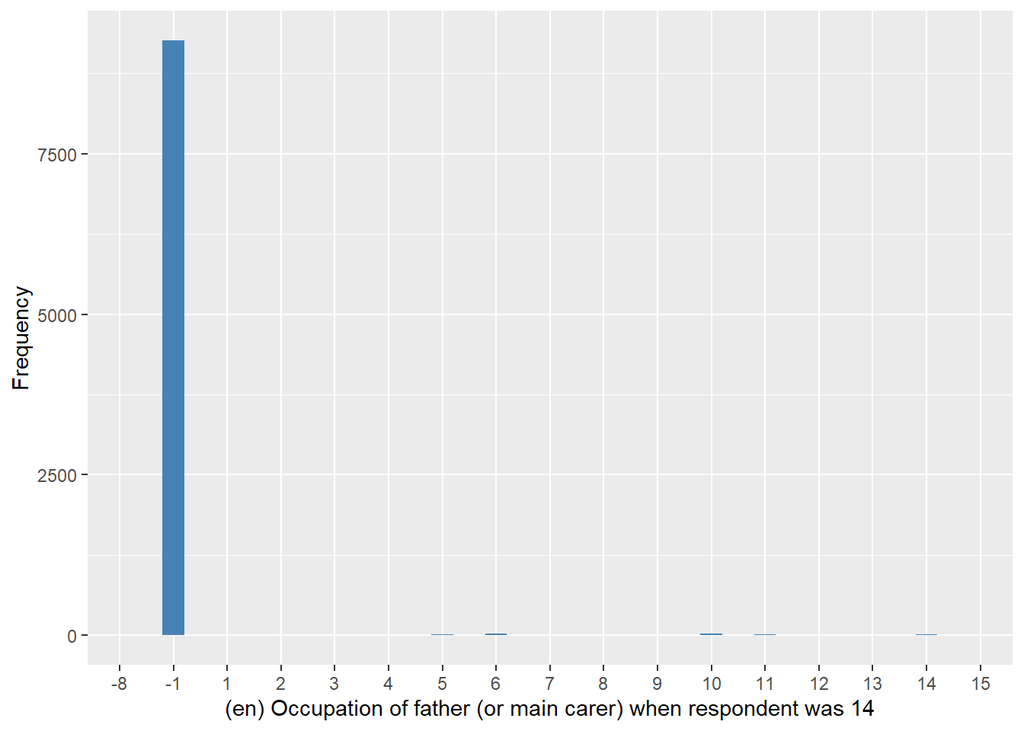

Data of individuals in waves 1 and 2

|  | -8 | -1 | 1 | 4 | 5 | 6 | 7 | 8 | 9 | 10 | 11 | 12 | 13 | 14 | 15 |
| --- | --- | --- | --- | --- | --- | --- | --- | --- | --- | --- | --- | --- | --- | --- | --- |
| -9 | 0 | 0 | 0 | 0 | 0 | 0 | 0 | 0 | 0 | 1 | 0 | 0 | 0 | 1 | 0 |
| -8 | 5 | 0 | 2 | 2 | 4 | 6 | 5 | 4 | 2 | 9 | 12 | 1 | 2 | 6 | 1 |
| -1 | 0 | 50 | 0 | 0 | 0 | 0 | 0 | 0 | 0 | 0 | 0 | 0 | 0 | 0 | 0 |
| 1 | 0 | 247 | 0 | 0 | 0 | 0 | 0 | 0 | 0 | 0 | 0 | 0 | 0 | 0 | 0 |
| 2 | 0 | 445 | 0 | 0 | 0 | 0 | 0 | 0 | 0 | 0 | 0 | 0 | 0 | 0 | 0 |
| 3 | 0 | 706 | 0 | 0 | 0 | 0 | 0 | 0 | 0 | 0 | 0 | 0 | 0 | 0 | 0 |
| 4 | 0 | 1067 | 0 | 0 | 0 | 0 | 0 | 0 | 0 | 0 | 0 | 0 | 0 | 0 | 0 |
| 5 | 0 | 587 | 0 | 0 | 0 | 0 | 0 | 0 | 0 | 0 | 0 | 0 | 0 | 0 | 0 |
| 6 | 0 | 2561 | 0 | 0 | 0 | 0 | 0 | 0 | 0 | 0 | 0 | 0 | 0 | 0 | 0 |
| 7 | 0 | 164 | 0 | 0 | 0 | 0 | 0 | 0 | 0 | 0 | 0 | 0 | 0 | 0 | 0 |
| 8 | 0 | 247 | 0 | 0 | 0 | 0 | 0 | 0 | 0 | 0 | 0 | 0 | 0 | 0 | 0 |
| 9 | 0 | 831 | 0 | 0 | 0 | 0 | 0 | 0 | 0 | 0 | 0 | 0 | 0 | 0 | 0 |
| 10 | 0 | 1427 | 0 | 0 | 0 | 0 | 0 | 0 | 0 | 0 | 0 | 0 | 0 | 0 | 0 |
| 11 | 0 | 508 | 0 | 0 | 0 | 0 | 0 | 0 | 0 | 0 | 0 | 0 | 0 | 0 | 0 |
| 12 | 0 | 120 | 0 | 0 | 0 | 0 | 0 | 0 | 0 | 0 | 0 | 0 | 0 | 0 | 0 |
| 13 | 0 | 69 | 0 | 0 | 0 | 0 | 0 | 0 | 0 | 0 | 0 | 0 | 0 | 0 | 0 |
| 14 | 0 | 129 | 0 | 0 | 0 | 0 | 0 | 0 | 0 | 0 | 0 | 0 | 0 | 0 | 0 |
| 15 | 0 | 103 | 0 | 0 | 0 | 0 | 0 | 0 | 0 | 0 | 0 | 0 | 0 | 0 | 0 |

#### 2.1.2.2 Harmonisation algorithm

To compute `childsep` from the study-specific variable it has to be recoded as follows:

- `keep childsep from wave 1`
- `1,5:8 into 1`
- `2:4 into 0`
- `9:12,14:15 into 2`
- `-9 into 997`
- `-8 into 998`
- `-1 into 996`
- `13 into 999`

**R script:**

```r
ELSA_ds_w2 <- ELSA_w2 %>%
  left_join(ELSA_ds, by = "id") %>%
  mutate(childsep.w2 = case_when(
    !childsep %in% c(991:999) & !is.na(childsep) ~ childsep,
    DiFJob %in% c(2:4) ~ 0,
    DiFJob %in% c(1,5:8) ~ 1,
    DiFJob %in% c(9:12,14:15) ~ 2,
    DiFJob %in% c(-9) ~ 997,
    DiFJob %in% c(-8) ~ 998,
    DiFJob %in% c(-1,-2) & !is.na(childsep) ~ childsep,
    DiFJob %in% c(-1,-2) & is.na(childsep) ~ 996,
    DiFJob %in% c(13) ~ 999,
    TRUE ~ 999
  )) %>%
  select(id, childsep = childsep.w2)

ELSA_ds <- ELSA_ds %>%
  full_join(ELSA_ds_w2 %>%
              mutate(misscode = case_when(
                childsep %in% c(991:999) ~ 1,
                TRUE ~ 0
              )), by = "id", suffix = c(".pw",".w2")) %>%
  mutate(childsep = case_when(
    !is.na(misscode.w2) ~ childsep.w2,
    is.na(misscode.w2) ~ childsep.pw
  )) %>%
  mutate(misscode = case_when(
    childsep %in% c(991:999) ~ 1,
    TRUE ~ 0
  )) %>%
  select(id, childsep, misscode)
```

#### 2.1.2.3 Statistical description of the new harmonised variable

Childhood socioeconomic position

| Sample size | Missing values |
| --- | --- |
| 9432 | 132 |

Category

|  | 0 | 1 | 2 |
| --- | --- | --- | --- |
| Frequency | 2240.00 | 3877.0 | 3183.00 |
| Percentage | 23.75 | 41.1 | 33.75 |

Type of missing

|  | 991 | 992 | 993 | 994 | 995 | 996 | 997 | 998 | 999 | NA |
| --- | --- | --- | --- | --- | --- | --- | --- | --- | --- | --- |
| Frequency | 0 | 0 | 0 | 0 | 0 | 50.00 | 0 | 10.00 | 72.00 | 0 |
| Percentage | 0 | 0 | 0 | 0 | 0 | 0.53 | 0 | 0.11 | 0.76 | 0 |

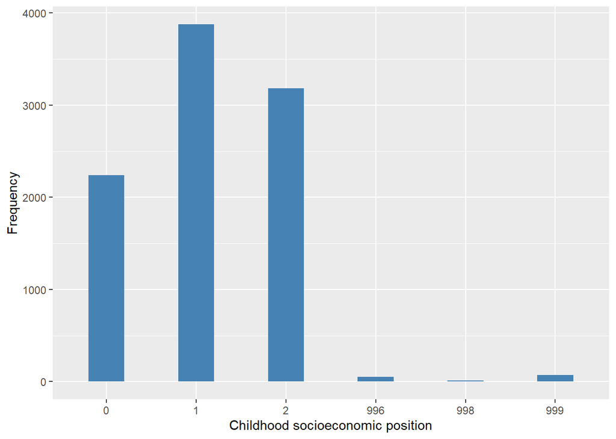

#### 2.1.2.4 Validation

### 2.1.3 Wave 3

#### 2.1.3.1 Study-specific variable description

| **Name** | `difjob` |
| --- | --- |
| **Label** | `What was your father~s (or main carer~s) job when you were 14?` |
| **Table name** | `wave_3_elsa_data_v4` |
| **Categories** | `1 = Armed Forces` `2 = Manager or senior official in someone else s business` `3 = Running his own business` `4 = Professional or technical` `5 = Administrative, clerical or secretarial` `6 = Skilled… |
| **Missings** | `-9 = Refusal` `-8 = Don't Know` `-2 = Schedule not applicable` `-1 = Not applicable` |
| **Description** |  |

DIFJOB

| Sample size | Missing values |
| --- | --- |
| 9771 | 8072 |

Category

|  | 1 | 2 | 3 | 4 | 5 | 6 | 7 | 8 | 9 | 10 | 11 | 12 | 13 | 14 | 15 |
| --- | --- | --- | --- | --- | --- | --- | --- | --- | --- | --- | --- | --- | --- | --- | --- |
| Frequency | 35.00 | 86.00 | 147.0 | 285.00 | 106.00 | 433.00 | 30.00 | 48.00 | 161.00 | 218.00 | 75.00 | 13.00 | 11.00 | 32.00 | 19.00 |
| Percentage | 0.36 | 0.88 | 1.5 | 2.92 | 1.08 | 4.43 | 0.31 | 0.49 | 1.65 | 2.23 | 0.77 | 0.13 | 0.11 | 0.33 | 0.19 |

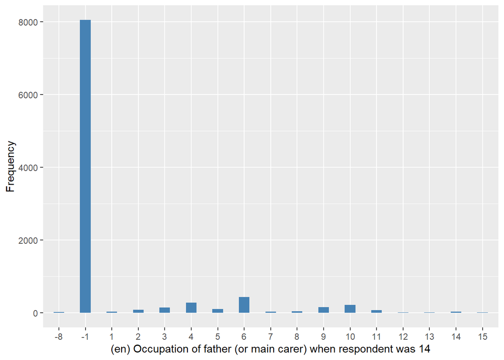

Data of individuals in waves 1 and 3

|  | -1 | 6 | 9 |
| --- | --- | --- | --- |
| -9 | 2 | 0 | 0 |
| -8 | 51 | 0 | 0 |
| -1 | 34 | 0 | 0 |
| 1 | 215 | 0 | 0 |
| 2 | 398 | 0 | 0 |
| 3 | 601 | 0 | 0 |
| 4 | 942 | 0 | 0 |
| 5 | 521 | 0 | 0 |
| 6 | 2151 | 1 | 1 |
| 7 | 143 | 0 | 0 |
| 8 | 220 | 0 | 0 |
| 9 | 702 | 0 | 0 |
| 10 | 1217 | 0 | 0 |
| 11 | 427 | 0 | 0 |
| 12 | 92 | 0 | 0 |
| 13 | 55 | 0 | 0 |
| 14 | 116 | 0 | 0 |
| 15 | 87 | 0 | 0 |

Data of individuals in waves 2 and 3

|  | -1 | 6 | 9 |
| --- | --- | --- | --- |
| -8 | 8 | 0 | 0 |
| -1 | 7564 | 1 | 1 |
| 1 | 4 | 0 | 0 |
| 2 | 2 | 0 | 0 |
| 3 | 8 | 0 | 0 |
| 4 | 6 | 0 | 0 |
| 5 | 8 | 0 | 0 |
| 6 | 21 | 0 | 0 |
| 7 | 6 | 0 | 1 |
| 8 | 6 | 0 | 0 |
| 9 | 5 | 0 | 0 |
| 10 | 17 | 0 | 0 |
| 11 | 12 | 0 | 0 |
| 14 | 10 | 0 | 0 |

#### 2.1.3.2 Harmonisation algorithm

To compute `childsep` from the study-specific variable it has to be recoded as follows:

- `keep childsep from previous waves`
- `1,5:8 into 1`
- `2:4 into 0`
- `9:12,14:15 into 2`
- `-9 into 997`
- `-8 into 998`
- `-1,-2 into 996`
- `13 into 999`

**R script:**

```r
ELSA_ds_w3 <- ELSA_w3 %>%
  left_join(ELSA_ds, by = "id") %>%
  mutate(childsep.w3 = case_when(
    !childsep %in% c(991:999) & !is.na(childsep) ~ childsep,
    difjob %in% c(2:4) ~ 0,
    difjob %in% c(1,5:8) ~ 1,
    difjob %in% c(9:12,14:15) ~ 2,
    difjob %in% c(-9) ~ 997,
    difjob %in% c(-8) ~ 998,
    difjob %in% c(-1,-2) & !is.na(childsep) ~ childsep,
    difjob %in% c(-1,-2) & is.na(childsep) ~ 996,
    difjob %in% c(13) ~ 999,
    TRUE ~ 999
  )) %>%
  select(id, childsep = childsep.w3)

ELSA_ds <- ELSA_ds %>%
  full_join(ELSA_ds_w3 %>%
              mutate(misscode = case_when(
                childsep %in% c(991:999) ~ 1,
                TRUE ~ 0
              )), by = "id", suffix = c(".pw",".w3")) %>%
  mutate(childsep = case_when(
    !is.na(misscode.w3) ~ childsep.w3,
    is.na(misscode.w3) ~ childsep.pw
  )) %>%
  mutate(misscode = case_when(
    childsep %in% c(991:999) ~ 1,
    TRUE ~ 0
  )) %>%
  select(id, childsep, misscode)
```

#### 2.1.3.3 Statistical description of the new harmonised variable

Childhood socioeconomic position

| Sample size | Missing values |
| --- | --- |
| 9771 | 146 |

Category

|  | 0 | 1 | 2 |
| --- | --- | --- | --- |
| Frequency | 2475.00 | 3949.00 | 3201.00 |
| Percentage | 25.33 | 40.42 | 32.76 |

Type of missing

|  | 991 | 992 | 993 | 994 | 995 | 996 | 997 | 998 | 999 | NA |
| --- | --- | --- | --- | --- | --- | --- | --- | --- | --- | --- |
| Frequency | 0 | 0 | 0 | 0 | 0 | 44.00 | 1.00 | 35.00 | 66.00 | 0 |
| Percentage | 0 | 0 | 0 | 0 | 0 | 0.45 | 0.01 | 0.36 | 0.68 | 0 |

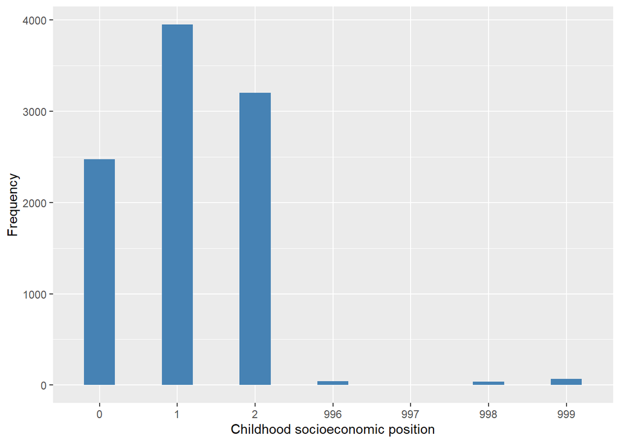

#### 2.1.3.4 Validation

### 2.1.4 Wave 4

#### 2.1.4.1 Study-specific variable description

| **Name** | `difjob` |
| --- | --- |
| **Label** | `What was your father~s (or main carer~s) job when you were 14?` |
| **Table name** | `wave_4_elsa_data_v3` |
| **Categories** | `1 = Armed Forces` `2 = Manager or senior official in someone else s business` `3 = Running his own business` `4 = Professional or technical` `5 = Administrative, clerical or secretarial` `6 = Skilled… |
| **Missings** | `-9 = Refusal` `-8 = Don't Know` `-2 = Schedule not applicable` `-1 = Not applicable` |
| **Description** |  |

DIFJOB

| Sample size | Missing values |
| --- | --- |
| 11050 | 8154 |

Category

|  | 1 | 2 | 3 | 4 | 5 | 6 | 7 | 8 | 9 | 10 | 11 | 12 | 13 | 14 | 15 |
| --- | --- | --- | --- | --- | --- | --- | --- | --- | --- | --- | --- | --- | --- | --- | --- |
| Frequency | 69.00 | 169.00 | 242.00 | 409.0 | 153.00 | 754.00 | 52.00 | 104.00 | 259.00 | 420.0 | 129.00 | 35.00 | 20.00 | 52.00 | 29.00 |
| Percentage | 0.62 | 1.53 | 2.19 | 3.7 | 1.38 | 6.82 | 0.47 | 0.94 | 2.34 | 3.8 | 1.17 | 0.32 | 0.18 | 0.47 | 0.26 |

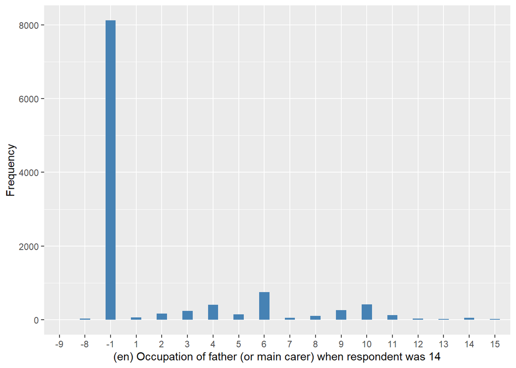

Data of individuals in waves 1 and 4

|  | -8 | -1 | 1 | 2 | 3 | 4 | 5 | 6 | 7 | 8 | 9 | 10 | 11 | 12 | 13 | 14 | 15 |
| --- | --- | --- | --- | --- | --- | --- | --- | --- | --- | --- | --- | --- | --- | --- | --- | --- | --- |
| -9 | 0 | 0 | 0 | 0 | 0 | 0 | 0 | 0 | 0 | 0 | 0 | 1 | 0 | 0 | 0 | 0 | 0 |
| -8 | 0 | 45 | 0 | 0 | 0 | 0 | 0 | 0 | 0 | 0 | 0 | 1 | 0 | 0 | 0 | 0 | 0 |
| -1 | 0 | 30 | 0 | 0 | 0 | 0 | 0 | 0 | 0 | 0 | 0 | 0 | 1 | 0 | 0 | 0 | 0 |
| 1 | 0 | 183 | 3 | 0 | 0 | 1 | 0 | 0 | 0 | 0 | 0 | 0 | 1 | 0 | 0 | 1 | 0 |
| 2 | 0 | 349 | 0 | 12 | 1 | 4 | 1 | 0 | 0 | 0 | 0 | 0 | 0 | 0 | 0 | 0 | 0 |
| 3 | 0 | 504 | 0 | 0 | 18 | 0 | 0 | 4 | 0 | 1 | 0 | 5 | 1 | 0 | 0 | 0 | 0 |
| 4 | 0 | 827 | 0 | 1 | 0 | 17 | 1 | 2 | 0 | 0 | 0 | 4 | 1 | 0 | 0 | 0 | 0 |
| 5 | 0 | 447 | 0 | 2 | 1 | 3 | 7 | 1 | 0 | 0 | 0 | 2 | 1 | 0 | 0 | 0 | 0 |
| 6 | 2 | 1818 | 2 | 2 | 3 | 8 | 1 | 39 | 0 | 2 | 12 | 10 | 7 | 0 | 1 | 1 | 0 |
| 7 | 0 | 116 | 0 | 0 | 0 | 1 | 0 | 2 | 1 | 0 | 0 | 2 | 1 | 0 | 0 | 0 | 0 |
| 8 | 0 | 190 | 0 | 1 | 0 | 0 | 2 | 1 | 0 | 3 | 1 | 1 | 0 | 0 | 0 | 1 | 0 |
| 9 | 2 | 596 | 0 | 0 | 1 | 0 | 1 | 3 | 0 | 0 | 6 | 3 | 0 | 0 | 0 | 0 | 0 |
| 10 | 1 | 1004 | 0 | 1 | 4 | 1 | 0 | 9 | 1 | 1 | 5 | 6 | 4 | 1 | 1 | 0 | 0 |
| 11 | 1 | 351 | 1 | 0 | 1 | 2 | 0 | 2 | 0 | 0 | 1 | 4 | 3 | 0 | 0 | 2 | 0 |
| 12 | 1 | 66 | 0 | 0 | 0 | 0 | 0 | 0 | 0 | 0 | 0 | 0 | 0 | 1 | 0 | 1 | 0 |
| 13 | 0 | 50 | 0 | 0 | 1 | 1 | 0 | 0 | 0 | 0 | 0 | 0 | 0 | 0 | 1 | 0 | 0 |
| 14 | 0 | 87 | 0 | 0 | 0 | 0 | 0 | 0 | 0 | 0 | 0 | 0 | 0 | 0 | 0 | 1 | 1 |
| 15 | 0 | 67 | 1 | 0 | 0 | 0 | 0 | 0 | 0 | 0 | 1 | 0 | 0 | 0 | 0 | 0 | 2 |

#### 2.1.4.2 Harmonisation algorithm

To compute `childsep` from the study-specific variable it has to be recoded as follows:

- `keep childsep from previous waves`
- `1,5:8 into 1`
- `2:4 into 0`
- `9:12,14:15 into 2`
- `-9 into 997`
- `-8 into 998`
- `-1 into 996`
- `13 into 999`

**R script:**

```r
ELSA_ds_w4 <- ELSA_w4 %>%
  left_join(ELSA_ds, by = "id") %>%
  mutate(childsep.w4 = case_when(
    !childsep %in% c(991:999) & !is.na(childsep) ~ childsep,
    difjob %in% c(2:4) ~ 0,
    difjob %in% c(1,5:8) ~ 1,
    difjob %in% c(9:12,14:15) ~ 2,
    difjob %in% c(-9) ~ 997,
    difjob %in% c(-8) ~ 998,
    difjob %in% c(-1,-2) & !is.na(childsep) ~ childsep,
    difjob %in% c(-1,-2) & is.na(childsep) ~ 996,
    difjob %in% c(13) ~ 999,
    TRUE ~ 999
  )) %>%
  select(id, childsep = childsep.w4)

ELSA_ds <- ELSA_ds %>%
  full_join(ELSA_ds_w4 %>%
              mutate(misscode = case_when(
                childsep %in% c(991:999) ~ 1,
                TRUE ~ 0
              )), by = "id", suffix = c(".pw",".w4")) %>%
  mutate(childsep = case_when(
    !is.na(misscode.w4) ~ childsep.w4,
    is.na(misscode.w4) ~ childsep.pw
  )) %>%
  mutate(misscode = case_when(
    childsep %in% c(991:999) ~ 1,
    TRUE ~ 0
  )) %>%
  select(id, childsep, misscode)
```

#### 2.1.4.3 Statistical description of the new harmonised variable

Childhood socioeconomic position

| Sample size | Missing values |
| --- | --- |
| 11050 | 213 |

Category

|  | 0 | 1 | 2 |
| --- | --- | --- | --- |
| Frequency | 2903.00 | 4443.00 | 3491.00 |
| Percentage | 26.27 | 40.21 | 31.59 |

Type of missing

|  | 991 | 992 | 993 | 994 | 995 | 996 | 997 | 998 | 999 | NA |
| --- | --- | --- | --- | --- | --- | --- | --- | --- | --- | --- |
| Frequency | 0 | 0 | 0 | 0 | 0 | 82.00 | 3.00 | 53.00 | 75.00 | 0 |
| Percentage | 0 | 0 | 0 | 0 | 0 | 0.74 | 0.03 | 0.48 | 0.68 | 0 |

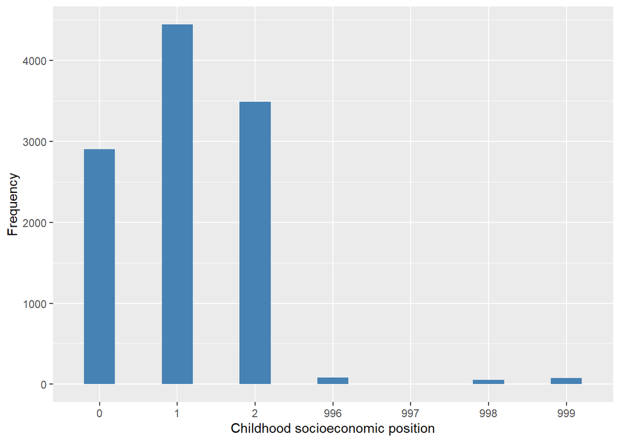

#### 2.1.4.4 Validation

### 2.1.5 Wave 5

#### 2.1.5.1 Study-specific variable description

| **Name** | `difjob` |
| --- | --- |
| **Label** | `What was your father~s (or main carer~s) job when you were 14?` |
| **Table name** | `wave_5_elsa_data_v4` |
| **Categories** | `1 = Armed Forces` `2 = Manager or senior official in someone else s business` `3 = Running his own business` `4 = Professional or technical` `5 = Administrative, clerical or secretarial` `6 = Skilled… |
| **Missings** | `-9 = Refusal` `-8 = Don't Know` `-2 = Schedule not applicable` `-1 = Not applicable` |
| **Description** |  |

DIFJOB

| Sample size | Missing values |
| --- | --- |
| 10274 | 9832 |

Category

|  | 1 | 2 | 3 | 4 | 5 | 6 | 7 | 8 | 9 | 10 | 11 | 12 | 13 | 14 | 15 |
| --- | --- | --- | --- | --- | --- | --- | --- | --- | --- | --- | --- | --- | --- | --- | --- |
| Frequency | 21.0 | 21.0 | 22.00 | 50.00 | 27.00 | 117.00 | 7.00 | 16.00 | 36.00 | 67.00 | 26.00 | 7.00 | 8.00 | 11.00 | 6.00 |
| Percentage | 0.2 | 0.2 | 0.21 | 0.49 | 0.26 | 1.14 | 0.07 | 0.16 | 0.35 | 0.65 | 0.25 | 0.07 | 0.08 | 0.11 | 0.06 |

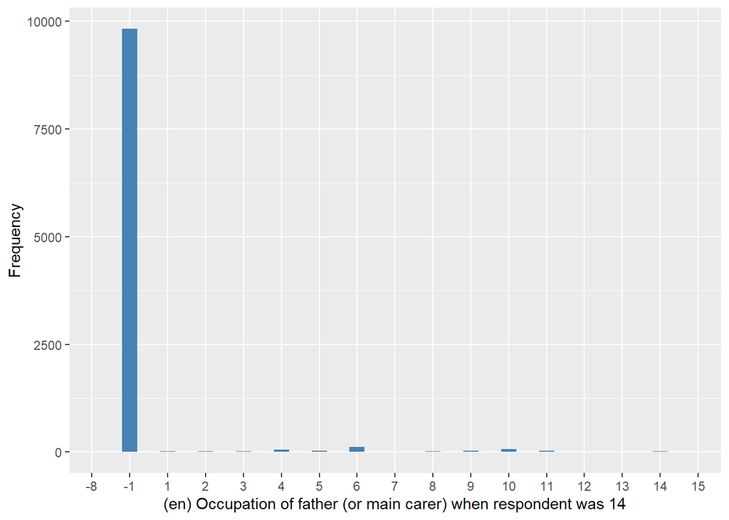

#### 2.1.5.2 Harmonisation algorithm

To compute `childsep` from the study-specific variable it has to be recoded as follows:

- `keep childsep from previous waves`
- `1,5:8 into 1`
- `2:4 into 0`
- `9:12,14:15 into 2`
- `-9 into 997`
- `-8 into 998`
- `-1 into 996`
- `13 into 999`

**R script:**

```r
ELSA_ds_w5 <- ELSA_w5 %>%
  left_join(ELSA_ds, by = "id") %>%
  mutate(childsep.w5 = case_when(
    !childsep %in% c(991:999) & !is.na(childsep) ~ childsep,
    difjob %in% c(2:4) ~ 0,
    difjob %in% c(1,5:8) ~ 1,
    difjob %in% c(9:12,14:15) ~ 2,
    difjob %in% c(-9) ~ 997,
    difjob %in% c(-8) ~ 998,
    difjob %in% c(-1,-2) & !is.na(childsep) ~ childsep,
    difjob %in% c(-1,-2) & is.na(childsep) ~ 996,
    difjob %in% c(13) ~ 999,
    TRUE ~ 999
  )) %>%
  select(id, childsep = childsep.w5)

ELSA_ds <- ELSA_ds %>%
  full_join(ELSA_ds_w5 %>%
              mutate(misscode = case_when(
                childsep %in% c(991:999) ~ 1,
                TRUE ~ 0
              )), by = "id", suffix = c(".pw",".w5")) %>%
  mutate(childsep = case_when(
    !is.na(misscode.w5) ~ childsep.w5,
    is.na(misscode.w5) ~ childsep.pw
  )) %>%
  mutate(misscode = case_when(
    childsep %in% c(991:999) ~ 1,
    TRUE ~ 0
  )) %>%
  select(id, childsep, misscode)
```

#### 2.1.5.3 Statistical description of the new harmonised variable

Childhood socioeconomic position

| Sample size | Missing values |
| --- | --- |
| 10274 | 179 |

Category

|  | 0 | 1 | 2 |
| --- | --- | --- | --- |
| Frequency | 2746.00 | 4133.00 | 3216.0 |
| Percentage | 26.73 | 40.23 | 31.3 |

Type of missing

|  | 991 | 992 | 993 | 994 | 995 | 996 | 997 | 998 | 999 | NA |
| --- | --- | --- | --- | --- | --- | --- | --- | --- | --- | --- |
| Frequency | 0 | 0 | 0 | 0 | 0 | 57.00 | 2.00 | 49.00 | 71.00 | 0 |
| Percentage | 0 | 0 | 0 | 0 | 0 | 0.55 | 0.02 | 0.48 | 0.69 | 0 |

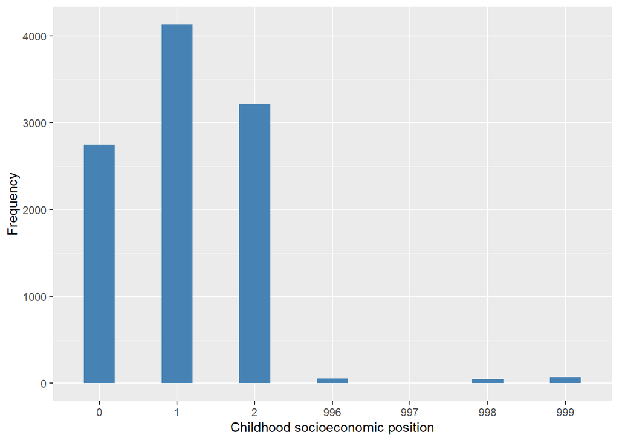

#### 2.1.5.4 Validation

### 2.1.6 Wave 6

#### 2.1.6.1 Study-specific variable description

| **Name** | `DiFJob` |
| --- | --- |
| **Label** | `What was your father~s (or main carer~s) job when you were 14?` |
| **Table name** | `wave_6_elsa_data_v2` |
| **Categories** | `1 = Armed Forces` `2 = Manager or senior official in someone else s business` `3 = Running his own business` `4 = Professional or technical` `5 = Administrative, clerical or secretarial` `6 = Skilled… |
| **Missings** | `-9 = Refusal` `-8 = Don't Know` `-2 = Schedule not applicable` `-1 = Not applicable` |
| **Description** |  |

DIFJOB

| Sample size | Missing values |
| --- | --- |
| 10601 | 9238 |

Category

|  | 1 | 2 | 3 | 4 | 5 | 6 | 7 | 8 | 9 | 10 | 11 | 12 | 13 | 14 | 15 |
| --- | --- | --- | --- | --- | --- | --- | --- | --- | --- | --- | --- | --- | --- | --- | --- |
| Frequency | 36.00 | 69.00 | 111.00 | 226.00 | 81.00 | 345.00 | 23.00 | 39.00 | 131.00 | 173.00 | 69.00 | 14.00 | 12.00 | 22.00 | 12.00 |
| Percentage | 0.34 | 0.65 | 1.05 | 2.13 | 0.76 | 3.25 | 0.22 | 0.37 | 1.24 | 1.63 | 0.65 | 0.13 | 0.11 | 0.21 | 0.11 |

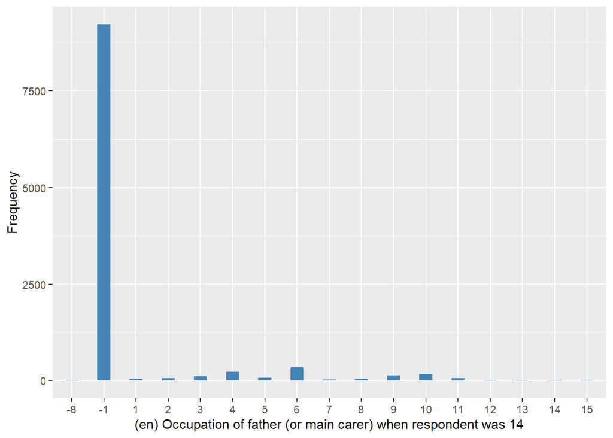

#### 2.1.6.2 Harmonisation algorithm

To compute `childsep` from the study-specific variable it has to be recoded as follows:

- `keep childsep from previous waves`
- `1,5:8 into 1`
- `2:4 into 0`
- `9:12,14:15 into 2`
- `-9 into 997`
- `-8 into 998`
- `-1 into 996`
- `13 into 999`

**R script:**

```r
ELSA_ds_w6 <- ELSA_w6 %>%
  left_join(ELSA_ds, by = "id") %>%
  mutate(childsep.w6 = case_when(
    !childsep %in% c(991:999) & !is.na(childsep) ~ childsep,
    DiFJob %in% c(2:4) ~ 0,
    DiFJob %in% c(1,5:8) ~ 1,
    DiFJob %in% c(9:12,14:15) ~ 2,
    DiFJob %in% c(-9) ~ 997,
    DiFJob %in% c(-8) ~ 998,
    DiFJob %in% c(-1,-2) & !is.na(childsep) ~ childsep,
    DiFJob %in% c(-1,-2) & is.na(childsep) ~ 996,
    DiFJob %in% c(13) ~ 999,
    TRUE ~ 999
  )) %>%
  select(id, childsep = childsep.w6)

ELSA_ds <- ELSA_ds %>%
  full_join(ELSA_ds_w6 %>%
              mutate(misscode = case_when(
                childsep %in% c(991:999) ~ 1,
                TRUE ~ 0
              )), by = "id", suffix = c(".pw",".w6")) %>%
  mutate(childsep = case_when(
    !is.na(misscode.w6) ~ childsep.w6,
    is.na(misscode.w6) ~ childsep.pw
  )) %>%
  mutate(misscode = case_when(
    childsep %in% c(991:999) ~ 1,
    TRUE ~ 0
  )) %>%
  select(id, childsep, misscode)
```

#### 2.1.6.3 Statistical description of the new harmonised variable

Childhood socioeconomic position

| Sample size | Missing values |
| --- | --- |
| 10601 | 187 |

Category

|  | 0 | 1 | 2 |
| --- | --- | --- | --- |
| Frequency | 2883.0 | 4266.00 | 3265.0 |
| Percentage | 27.2 | 40.24 | 30.8 |

Type of missing

|  | 991 | 992 | 993 | 994 | 995 | 996 | 997 | 998 | 999 | NA |
| --- | --- | --- | --- | --- | --- | --- | --- | --- | --- | --- |
| Frequency | 0 | 0 | 0 | 0 | 0 | 58.00 | 2.00 | 57.00 | 70.00 | 0 |
| Percentage | 0 | 0 | 0 | 0 | 0 | 0.55 | 0.02 | 0.54 | 0.66 | 0 |

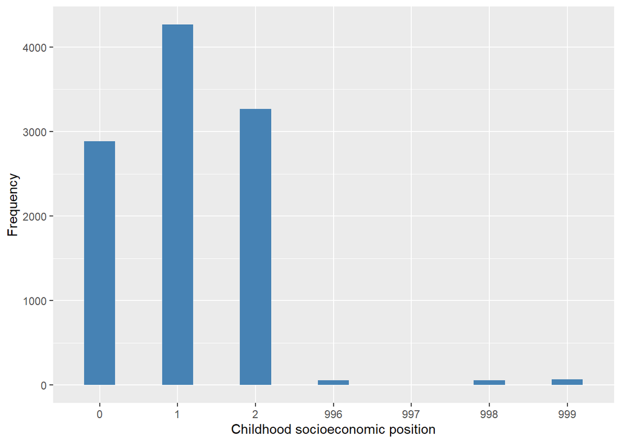

#### 2.1.6.4 Validation

### 2.1.7 Wave 7

#### 2.1.7.1 Study-specific variable description

| **Name** | `DiFJob` |
| --- | --- |
| **Label** | `What was your father~s (or main carer~s) job when you were 14?` |
| **Table name** | `wave_7_elsa_data` |
| **Categories** | `1 = Armed Forces` `2 = Manager or senior official in someone else s business` `3 = Running his own business` `4 = Professional or technical` `5 = Administrative, clerical or secretarial` `6 = Skilled… |
| **Missings** | `-9 = Refusal` `-8 = Don't Know` `-2 = Schedule not applicable` `-1 = Not applicable` |
| **Description** |  |

| Sample size | Missing values |
| --- | --- |
| 9666 | 9076 |

Category

|  | 1 | 2 | 3 | 4 | 5 | 6 | 7 | 8 | 9 | 10 | 11 | 12 | 13 | 14 | 15 |
| --- | --- | --- | --- | --- | --- | --- | --- | --- | --- | --- | --- | --- | --- | --- | --- |
| Frequency | 15.00 | 25.00 | 49.00 | 100.00 | 34.00 | 153.00 | 9.00 | 18.00 | 71.00 | 70.00 | 27.00 | 5.00 | 2.00 | 6.00 | 6.00 |
| Percentage | 0.16 | 0.26 | 0.51 | 1.03 | 0.35 | 1.58 | 0.09 | 0.19 | 0.73 | 0.72 | 0.28 | 0.05 | 0.02 | 0.06 | 0.06 |

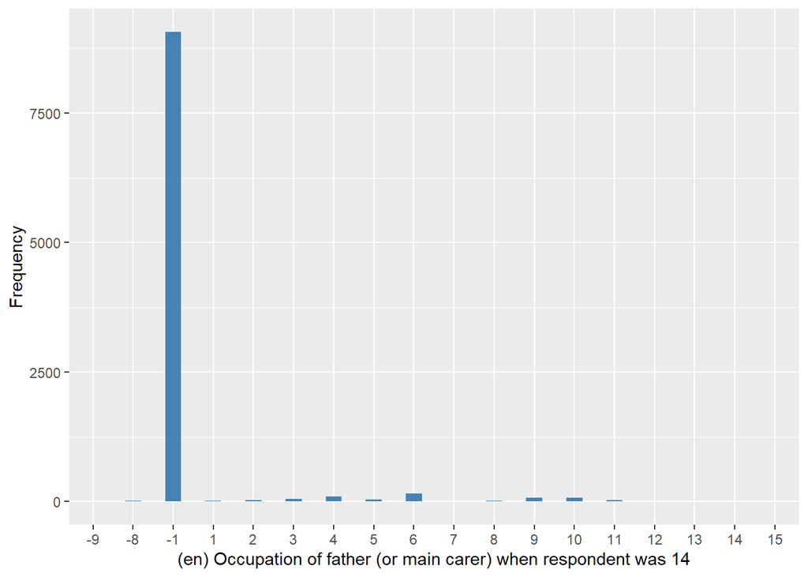

#### 2.1.7.2 Harmonisation algorithm

To compute `childsep` from the study-specific variable it has to be recoded as follows:

- `keep childsep from previous waves`
- `1,5:8 into 1`
- `2:4 into 0`
- `9:12,14:15 into 2`
- `-9 into 997`
- `-8 into 998`
- `-1 into 996`
- `13 into 999`

**R script:**

```r
ELSA_ds_w7 <- ELSA_w7 %>%
  left_join(ELSA_ds, by = "id") %>%
  mutate(childsep.w7 = case_when(
    !childsep %in% c(991:999) & !is.na(childsep) ~ childsep,
    DiFJob %in% c(2:4) ~ 0,
    DiFJob %in% c(1,5:8) ~ 1,
    DiFJob %in% c(9:12,14:15) ~ 2,
    DiFJob %in% c(-9) ~ 997,
    DiFJob %in% c(-8) ~ 998,
    DiFJob %in% c(-1,-2) & !is.na(childsep) ~ childsep,
    DiFJob %in% c(-1,-2) & is.na(childsep) ~ 996,
    DiFJob %in% c(13) ~ 999,
    TRUE ~ 999
  )) %>%
  select(id, childsep = childsep.w7)

rm(ELSA_ds)
```

#### 2.1.7.3 Statistical description of the new harmonised variable

Childhood socioeconomic position

| Sample size | Missing values |
| --- | --- |
| 9666 | 170 |

Category

|  | 0 | 1 | 2 |
| --- | --- | --- | --- |
| Frequency | 2704.00 | 3883.00 | 2909.0 |
| Percentage | 27.97 | 40.17 | 30.1 |

Type of missing

|  | 991 | 992 | 993 | 994 | 995 | 996 | 997 | 998 | 999 | NA |
| --- | --- | --- | --- | --- | --- | --- | --- | --- | --- | --- |
| Frequency | 0 | 0 | 0 | 0 | 0 | 54.00 | 3.00 | 52.00 | 61.00 | 0 |
| Percentage | 0 | 0 | 0 | 0 | 0 | 0.56 | 0.03 | 0.54 | 0.63 | 0 |

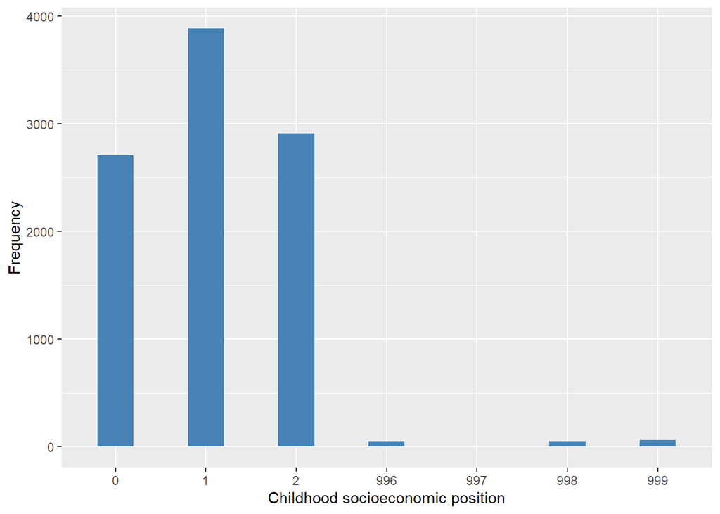

#### 2.1.7.4 Validation

## 2.2 Summary of descriptive statistics of the harmonised variable accross populations and waves

Two tables are generated:

1. Percentages of categories in each harmonised variable.
2. Frequencies and percentages of individuals with different trajectories. To avoid too large table, Only trajectories with percentages larger than 0.3 are shown.

Childhood socioeconomic position

| val | label | W1 | W2 | W3 | W4 | W5 | W6 | W7 |
| --- | --- | --- | --- | --- | --- | --- | --- | --- |
| 0 | High | 22.81 | 23.75 | 25.33 | 26.27 | 26.73 | 27.2 | 27.97 |
| 1 | Medium | 40.68 | 41.1 | 40.42 | 40.21 | 40.23 | 40.24 | 40.17 |
| 2 | Low | 34.22 | 33.75 | 32.76 | 31.59 | 31.3 | 30.8 | 30.1 |
| 991 | CAPI interviewer error | 0 | 0 | 0 | 0 | 0 | 0 | 0 |
| 992 | Impute | 0 | 0 | 0 | 0 | 0 | 0 | 0 |
| 993 | Disable to measure | 0 | 0 | 0 | 0 | 0 | 0 | 0 |
| 994 | Not attempt not done | 0 | 0 | 0 | 0 | 0 | 0 | 0 |
| 995 | Does not answer | 0 | 0 | 0 | 0 | 0 | 0 | 0 |
| 996 | Not applicable | 0.65 | 0.53 | 0.45 | 0.74 | 0.55 | 0.55 | 0.56 |
| 997 | Refuse | 0.05 | 0 | 0.01 | 0.03 | 0.02 | 0.02 | 0.03 |
| 998 | Do not know | 0.82 | 0.11 | 0.36 | 0.48 | 0.48 | 0.54 | 0.54 |
| 999 | Missing | 0.77 | 0.76 | 0.68 | 0.68 | 0.69 | 0.66 | 0.63 |
| NA | NA | 0 | 0 | 0 | 0 | 0 | 0 | 0 |
| n | sample size | 12099 | 9432 | 9771 | 11050 | 10274 | 10601 | 9666 |

|  | val | frq | raw.prc |
| --- | --- | --- | --- |
| 1 | 0000000 | 1175 | 6.36 |
| 2 | 000000NA | 154 | 0.83 |
| 4 | 00000NANA | 102 | 0.55 |
| 8 | 0000NANANA | 121 | 0.65 |
| 16 | 000NANANANA | 191 | 1.03 |
| 30 | 00NANANANANA | 257 | 1.39 |
| 56 | 0NANANANANANA | 387 | 2.09 |
| 57 | 1111111 | 1800 | 9.74 |
| 58 | 111111NA | 268 | 1.45 |
| 60 | 11111NANA | 204 | 1.10 |
| 64 | 1111NANANA | 258 | 1.40 |
| 72 | 111NANANANA | 378 | 2.04 |
| 73 | 11NA1111 | 55 | 0.30 |
| 88 | 11NANANANANA | 513 | 2.77 |
| 115 | 1NANANANANANA | 844 | 4.56 |
| 116 | 2222222 | 1337 | 7.23 |
| 117 | 222222NA | 245 | 1.33 |
| 119 | 22222NANA | 179 | 0.97 |
| 123 | 2222NANANA | 228 | 1.23 |
| 131 | 222NANANANA | 353 | 1.91 |
| 147 | 22NANANANANA | 483 | 2.61 |
| 175 | 2NANANANANANA | 776 | 4.20 |
| 213 | NANA00000 | 282 | 1.53 |
| 226 | NANA0NANANANA | 81 | 0.44 |
| 227 | NANA11111 | 317 | 1.71 |
| 241 | NANA1NANANANA | 116 | 0.63 |
| 242 | NANA22222 | 255 | 1.38 |
| 257 | NANA2NANANANA | 99 | 0.54 |
| 258 | NANANA0000 | 496 | 2.68 |
| 259 | NANANA000NA | 62 | 0.34 |
| 265 | NANANA0NANANA | 88 | 0.48 |
| 266 | NANANA1111 | 673 | 3.64 |
| 267 | NANANA111NA | 92 | 0.50 |
| 269 | NANANA11NANA | 67 | 0.36 |
| 273 | NANANA1NANANA | 133 | 0.72 |
| 274 | NANANA2222 | 494 | 2.67 |
| 275 | NANANA222NA | 101 | 0.55 |
| 277 | NANANA22NANA | 62 | 0.34 |
| 281 | NANANA2NANANA | 127 | 0.69 |
| 294 | NANANANANA00 | 284 | 1.54 |
| 295 | NANANANANA0NA | 86 | 0.47 |
| 296 | NANANANANA11 | 357 | 1.93 |
| 297 | NANANANANA1NA | 98 | 0.53 |
| 298 | NANANANANA22 | 282 | 1.53 |
| 299 | NANANANANA2NA | 75 | 0.41 |
| 300 | NANANANANANA0 | 147 | 0.80 |
| 301 | NANANANANANA1 | 202 | 1.09 |
| 302 | NANANANANANA2 | 144 | 0.78 |
| 303 | NANANANANANANA | 396 | 2.14 |

# 3 Quality estimation